# 2023 Food Rankings

Amy Shuff

2023-05-09

Our 2023 Food Rankings analyze data from the 2022 Program Year (2021-2022 data).

The code used to create our rankings is available to the public on [github](https://github.com/amyshuff/Food-Rankings-2021-2022).

## Methodology Overview

We only include districts that have at least 10,000 students and at least 60% economically disadvantaged student population.

District scores were calculated as follows

- 25% lunch participation percent
- 50% breakfast participation percent
- 10% serving supper
- 15% serving after school snacks

Participation percents were found by combining all breakfast and lunch meals served by School Nutrition Program (SNP) and Seamless Summer Option (SSO) in each district, then dividing by the total number of students. Previous years rankings have used the number of students that qualified for free and reduced meals. Total enrollment was used this year since every student had access to free meals during the 2021-2022 school year.

Credit for serving supper or afterschool snacks was given to a district if they had at least one participating location. Supper data was from the Child and Adult Care Food Program (CACFP), and after school snacks were from any TDA program.

Meal count data was supplied by the Texas Department of Agriculture (TDA). District enrollment numbers came from the Texas Education Agency (TEA).

# Data Sources

## Texas Education Agency (TEA)

- Total Enrollment Counts in Student Program and Special Populations Reports, PEIMS Data 2021-2022

TEA data was obtained via Public Records Request. From this data we use the student enrollment counts and economically disadvantaged counts.

Student enrollment for small campuses are masked. In the case of the reported number being <10, we use 10. This means our district student counts are a slight overestimate.

Economically disadvantaged counts are sometimes unavailable, so in that case they are assumed zero.

Percent economically disadvantaged for each district is calculated from the campus student counts.

## Texas Department of Agriculture (TDA)

### School Nutrition Program (SNP)

- Although we obtained our data from a public information request, it is also available on the [Food and Nutrition Meals Served Dashboard, 2021-2022](https://data.texas.gov/stories/s/2021-2022-TDA-Food-and-Nutrition-Meals-Served-Dash/93tt-ffn6)

SNP Data includes meal counts from the National School Lunch Program (NSLP) and the School Breakfast Program (SBP).

Credit for participating in the Community Eligible Provision (CEP) was given to the entire district if they had any participating location.

### Seamless Summer Option (SSO)

SSO data was obtained from the TDA F&N Meals Served Dashboard.

- [2021-2022 Monthly SNP & SSO School Meal Count](https://data.texas.gov/dataset/2021-2022-Monthly-School-Meal-Count/dyrd-amq2)

Note from the data dashboard: “In March 2020, USDA began allowing flexibility in nutrition assistance program policies to support continued meal access during the coronavirus pandemic (COVID-19). This included offering School Nutrition Program sponsors the option to provide meals through Seamless Summer Option (SSO) in program year 2021-2022.”

The SSO is what schools used to offer free meals to all students regardless of income. Because of this, we are choosing to look at total number of meals served instead of only the free and reduced as we’ve done in years past. This option will not be available next year because the program has ended.

### Child and Adult Care Food Program (CACFP)

- [Child and Adult Care Food Programs (CACFP) – At Risk– Meal Reimbursement – Program Year 2021-2022](https://data.texas.gov/dataset/Child-and-Adult-Care-Food-Programs-CACFP-At-Risk-M/e4wr-4i5j)

CACFP data captures meals (supper) served in At-Risk afterschool care centers.

# Analysis

## Harmony Districts

Harmony Public Schools are listed under multiple district numbers (101858, 101862, 71806, 15828, 161807, 101846, 227816) in both the TEA and TDA data, but we combine them and consider them as a single district.

## Aggregate data up to district level

TDA data is reported monthly by Contracting Entities (CE) and participating sites. Usually October is used as the snapshot claim month for the year. This year fewer sites reported to TDA, and those that did didn’t report every month, instead favoring SSO for meal reimbursement, so we used their maximum claim month for the year instead.

Breakfast and lunch average daily participation (ADP) rates were found by dividing all meals served by the number of days meals were served.

Then the percent of breakfast and lunch participation was found by dividing their respective ADPs by the total number of students, as reported by the TEA data.

Our previous rankings found the percent of breakfast and lunch participation by dividing the free and reduced meals by the students that were eligible for them. We are looking at all meals for all students this year, since everyone was eligible for a free meal with SSO.

Credit for supper and snacks was given if any were offered by any site in the district at any point in the year.

## State Rankings

Top 10 Districts Overall

| District Name | School Type | Rank | County | ESC Region | Total Enrollment | % Economically Disadvantaged | Overall Score | % Lunch Participation | % Breakfast Participation | CACFP Supper | Afterschool Snack | CEP |
| --- | --- | --- | --- | --- | --- | --- | --- | --- | --- | --- | --- | --- |
| CLINT ISD | Public | 1 | EL PASO | 19 | 10,494 | 86.7 | 82.7 | 71.2 | 79.9 | Yes | Yes | Yes |
| DONNA ISD | Public | 2 | HIDALGO | 1 | 13,080 | 93.9 | 81.3 | 80.1 | 72.5 | Yes | Yes | Yes |
| IDEA ACADEMY | Charter | 3 | HIDALGO | 1 | 67,988 | 83.3 | 81.1 | 79.5 | 72.3 | Yes | Yes | Yes |
| HARLANDALE ISD | Public | 4 | BEXAR | 20 | 12,094 | 88.0 | 77.1 | 64.2 | 72.2 | Yes | Yes | Yes |
| MCALLEN ISD | Public | 5 | HIDALGO | 1 | 20,410 | 73.8 | 77.0 | 70.5 | 68.7 | Yes | Yes | Yes |
| EAGLE PASS ISD | Public | 6 | MAVERICK | 20 | 13,385 | 83.1 | 71.3 | 64.3 | 80.4 | No | Yes | Yes |
| LA JOYA ISD | Public | 7 | HIDALGO | 1 | 24,163 | 93.2 | 71.1 | 73.4 | 55.6 | Yes | Yes | Yes |
| EDINBURG ISD | Public | 8 | HIDALGO | 1 | 32,078 | 82.2 | 68.4 | 75.5 | 49.1 | Yes | Yes | Yes |
| SAN ANTONIO ISD | Public | 9 | BEXAR | 20 | 44,731 | 87.9 | 67.3 | 67.1 | 51.1 | Yes | Yes | Yes |
| HARLINGEN CONS ISD | Public | 10 | CAMERON | 1 | 17,037 | 76.5 | 66.9 | 71.9 | 47.8 | Yes | Yes | Yes |

## Large public districts

Districts are considered large if they have at least 50,000 students. Public district here specifically means it is not a charter district.

Top 5 Large Districts

| District Name | Rank | County | ESC Region | Total Enrollment | % Economically Disadvantaged | Overall Score | % Lunch Participation | % Breakfast Participation | CACFP Supper | Afterschool Snack | CEP |
| --- | --- | --- | --- | --- | --- | --- | --- | --- | --- | --- | --- |
| ALDINE ISD | 1 | HARRIS | 4 | 61,642 | 89.7 | 61.8 | 70.6 | 38.4 | Yes | Yes | No |
| HOUSTON ISD | 2 | HARRIS | 4 | 194,622 | 79.2 | 58.5 | 55.2 | 39.4 | Yes | Yes | Yes |
| DALLAS ISD | 3 | DALLAS | 10 | 143,574 | 85.1 | 57.6 | 60.9 | 34.7 | Yes | Yes | Yes |
| GARLAND ISD | 4 | DALLAS | 10 | 53,685 | 73.9 | 53.5 | 63.6 | 25.2 | Yes | Yes | Yes |
| ARLINGTON ISD | 5 | TARRANT | 11 | 56,311 | 72.7 | 53.1 | 62.1 | 25.2 | Yes | Yes | Yes |

## Middle-income districts

Districts are considered middle-income if they have 60-70% economically disadvantaged student population. This takes out high poverty schools and focuses on those which often face more challenges in implementing school food programs to scale.

Top 5 Middle-income Districts

| District Name | Rank | County | ESC Region | Total Enrollment | % Economically Disadvantaged | Overall Score | % Lunch Participation | % Breakfast Participation | CACFP Supper | Afterschool Snack | CEP |
| --- | --- | --- | --- | --- | --- | --- | --- | --- | --- | --- | --- |
| JUDSON ISD | 1 | BEXAR | 20 | 24,552 | 68.4 | 65.8 | 67.5 | 47.8 | Yes | Yes | Yes |
| WICHITA FALLS ISD | 2 | WICHITA | 9 | 13,380 | 65.8 | 63.9 | 69.7 | 42.9 | Yes | Yes | No |
| NEW CANEY ISD | 3 | MONTGOMERY | 6 | 17,116 | 67.1 | 52.3 | 72.5 | 38.3 | No | Yes | No |
| EAST CENTRAL ISD | 4 | BEXAR | 20 | 10,018 | 66.2 | 51.1 | 63.4 | 40.5 | No | Yes | Yes |
| VICTORIA ISD | 5 | VICTORIA | 3 | 13,315 | 68.5 | 50.4 | 58.2 | 21.7 | Yes | Yes | Yes |

## Charter School Districts

Charter School Districts

| District Name | School Type | State Rank | County | ESC Region | Total Enrollment | % Economically Disadvantaged | Overall Score | % Lunch Participation | % Breakfast Participation | CACFP Supper | Afterschool Snack | CEP |
| --- | --- | --- | --- | --- | --- | --- | --- | --- | --- | --- | --- | --- |
| IDEA ACADEMY | Charter | 3 | HIDALGO | 1 | 67,988 | 83.3 | 81.1 | 79.5 | 72.3 | Yes | Yes | Yes |
| YES PREP PUBLIC SCHOOLS, INC. | Charter | 46 | HARRIS | 4 | 14,562 | 90.0 | 46.9 | 52.1 | 17.7 | Yes | Yes | Yes |
| KIPP SCHOOLS | Charter | 60 | TRAVIS | 13 | 32,321 | 91.1 | 38.2 | 45.5 | 33.6 | Yes | No | Yes |
| INTERNATIONAL LEADERSHIP OF TEXAS, INC. | Charter | 63 | DALLAS | 10 | 20,538 | 61.5 | 33.7 | 58.1 | 18.3 | Yes | No | Yes |
| UPLIFT EDUCATION-NORTH HILLS PREPARATORY | Charter | 64 | DALLAS | 10 | 22,183 | 72.9 | 32.0 | 63.7 | 32.2 | No | No | No |

There are 5 charter districts that meet our ranking criteria. IDEA ACADEMY is the highest performing, ranked #3 in the state.

# Key Take-Aways

# Regional Rankings

Regionally-specific tables for press releases in Houston (Region 4), El Paso (Region 19), RGV (Region 1), and San Antonio (Region 20).

Top 3 Region 1 School Districts

| Region Rank | State Rank | District Name |
| --- | --- | --- |
| 1 | 2 | DONNA ISD |
| 2 | 3 | IDEA ACADEMY |
| 3 | 5 | MCALLEN ISD |

Top 3 Region 4 School Districts

| Region Rank | State Rank | District Name |
| --- | --- | --- |
| 1 | 14 | SPRING ISD |
| 2 | 20 | ALDINE ISD |
| 3 | 21 | GOOSE CREEK CISD |

Top 3 Region 19 School Districts

| Region Rank | State Rank | District Name |
| --- | --- | --- |
| 1 | 1 | CLINT ISD |
| 2 | 43 | SOCORRO ISD |
| 3 | 47 | YSLETA ISD |

Top 3 Region 20 School Districts

| Region Rank | State Rank | District Name |
| --- | --- | --- |
| 1 | 4 | HARLANDALE ISD |
| 2 | 6 | EAGLE PASS ISD |
| 3 | 9 | SAN ANTONIO ISD |

# Comparison to School Performance

I wanted to see if our food rankings score correlated with school performance. I looked at TEA’s reported Overall Score, Student Achievement Score, Academic Growth Score, Relative Performance Score, School Progress Score, and Closing the Gaps Score.

Only the Academic Growth Score showed a positive correlation. But when I took out our filters (over 10,000 students and over 60% eco.dis) then the correlation was negative. I think it was just by chance that for these particular school districts there happened to be a positive correlation.

The strongest relationship was found with the percent of economically disadvantaged students. But once again this relationship disappears when I take out our filters (over 10,000 students and over 60% eco.dis).

This graph highlights just how poorly Kipp Schools and Yes Prep are doing at feeding their students. They are the only schools in our rankings that have an over 90% economically disadvantaged student population and still received a score under 50 from us. Less than half the students at Kipp Schools participate in their lunch program.

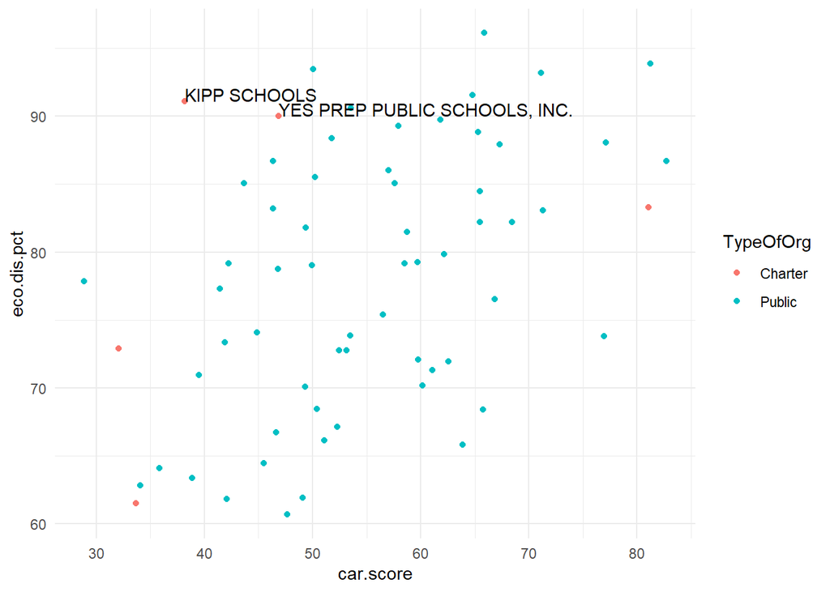

# Longitudinal Data

- [2021-2022 Monthly SNP & SSO School Meal Count](https://data.texas.gov/dataset/2021-2022-Monthly-School-Meal-Count/dyrd-amq2)
- [Meal and Reimbursement Data, Program Years 2015-2019](https://data.texas.gov/stories/s/e2dm-5r4v)

Because the last two years had an unprecedented number of free meals available to students due to covid relief money, we wanted to see what impact that had on the total number of meals served and average daily participation. This will be especially interesting to look at next year now that the programs have ended.

Note that 2020-2021 and 2019-2020 were left out intentionally, as we just wanted to compare to pre-pandemic levels.

Looking at the total number of breakfast and lunch meals served to all students from year to year, the number actually decreased for 2021-2022. Could be due to staffing issues, supply issues, and school shut downs.

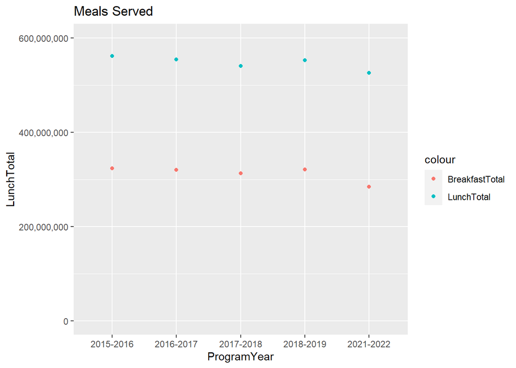

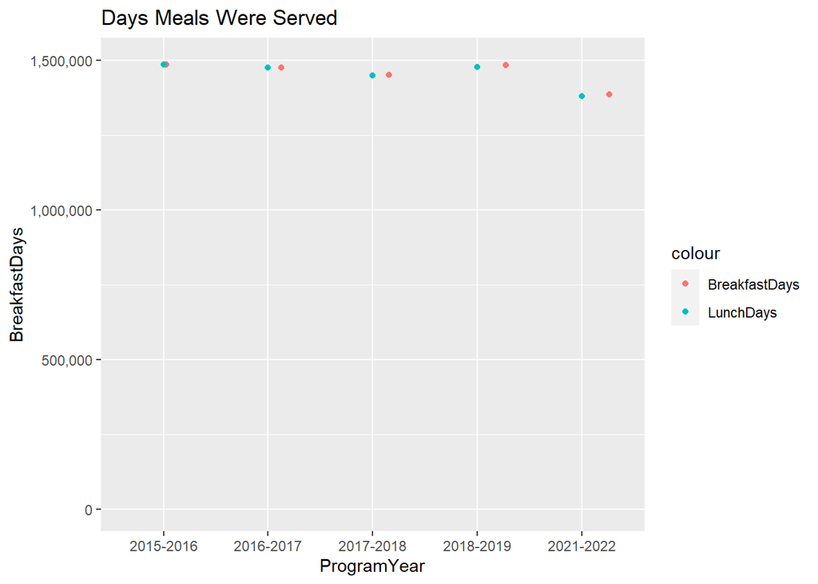

Finding the average daily participation rates (Total Meals divided by Total Days Served).

Note that the data is organized by site, so this is the average number of students served on each site each day. The rate was slightly higher in 2021-2022 for lunch but not for breakfast.

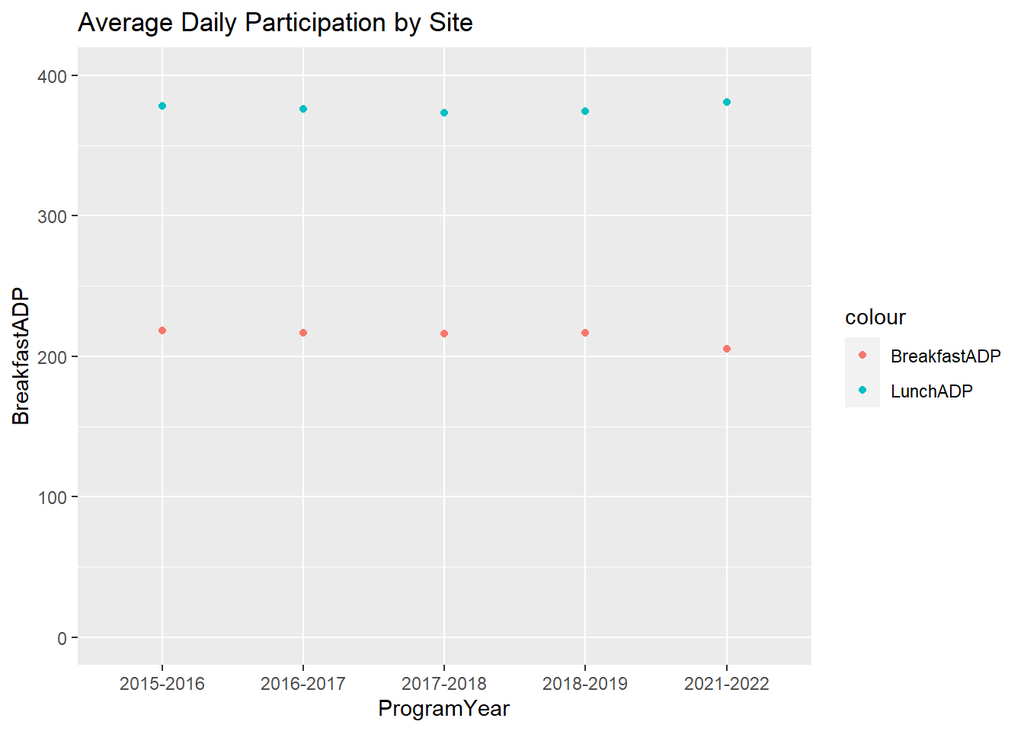